# GDP and Income Group Analysis

Alex Norman

October 30, 2016

# Introduction

We are analyzing the Gross Domestic Product and Income Groups for all the countries. We have two datasets, Gross Domestic Product which will give us the GDP and ranking of all the countries, and Educational which will give us the Income Group for all the countries. With these datasets we will need to have clean and tidy data to do a proper analysis. All the work is split into multiple files by function and the files are * Libraries.R gives a list of the packages used in this analysis * Importing data.R contains the code to import the two datasets * cleaning and merging data.R contains the code for tidying the data and then merging the two datasets * data analysis.R contains the code and the answers to the questions asked

# Libraries

Below is the list of libraries loaded to be able to complete the tidying and analysis of the data.

```r
library(plyr)
library(dplyr)
library(data.table)
library(ggplot2)
library(repmis)
```

# Importing Data

```r
#Download and reading in the two data sets
gdp_raw <- read.csv ("https://d396qusza40orc.cloudfront.net/getdata%2Fdata%2FGDP.csv", header = TRUE)
edu_raw <- read.csv("https://d396qusza40orc.cloudfront.net/getdata%2Fdata%2FEDSTATS_Country.csv", header = TRUE)
```

# Cleaning the dataset

## Cleaning the GDP dataset

Clean data is needed to have an accurate analysis of the data. The GDP dataset had extra rows and columns that are not needed and will be removed. This dataset also had NAs and blanks with in the data.

```r
#Cleaning up gdp data
##removing columns that are all NAs or not useful information in gdp data
gdp <- gdp_raw[c(5:194, 196:219, 221, 223:235), c("X", "Gross.domestic.product.2012", "X.2", "X.3", "X.4")]
#renaming the column names
setnames(gdp, old = c('X', 'Gross.domestic.product.2012', 'X.2','X.3', 'X.4'),
         new = c('Code', 'Ranking', 'Country', 'GDP','Notes'))
##replacing rows with .. as the value of GDP to be NA
for(j in 1:nrow(gdp)){if(gdp$GDP[j] == ".." || gdp$GDP[j] == "") gdp$GDP[j] = NA}
#replaing all blank values with NA
for(i in 1:nrow(gdp)){ for(j in 1:ncol(gdp))  { if(!is.na(gdp[i,j])) if(gdp[i,j] == "") gdp[i,j] = NA }}
#reformatting numeric to be able to sort later
gdp$GDP <- as.numeric(gsub("[^[:digit:]]","", gdp$GDP))
gdp$Ranking <- as.numeric(gsub("[^[:digit:]]","", gdp$Ranking))

#removing all NANs from rank and gdp
gdp_nan <- subset(gdp, !(is.na(gdp$Ranking) | is.na(gdp$GDP)))

gdp_nan$GDP <- as.numeric(gsub("[^[:digit:]]","", gdp_nan$GDP))
gdp_nan$Ranking <- as.numeric(gsub("[^[:digit:]]","", gdp_nan$Ranking))
```

## Cleaning the Education dataset

The Education dataset was mostly clean we will want to only keep relavent columns in this dataset to save space. We also needed to make any blank values found in this dataset NA values.

```r
#Cleaning up education data
#selecting only the colmuns that we want and need for our analyze
edu <- edu_raw[, c("CountryCode",  "Income.Group", "Short.Name")]
for(i in 1:nrow(edu)){ for(j in 1:ncol(edu))  { if(!is.na(edu[i,j])) if(edu[i,j] == "") edu[i,j] = NA }}
```

# Merging of the datasets

```r
#Merging data
##With NAs in rank and GDP
GDP_final <- merge(gdp, edu, by.x = "Code", by.y = "CountryCode" )
##Without NAs
GDP_final_nan <- merge(gdp_nan, edu, by.x = "Code", by.y = "CountryCode" )
```

# Data Analysis

Our analysis will consist of five questions and the answers to better understand the GDP and Income Groups of all the countries. For analysis 1-3 I looked at the analysis with both NAs present in the GDP data and removing all NAs in the GDP dataset. ##Analysis 1 How many of the IDs match?

```r
#Qustion 1: How many of the IDs match?
##With NAs
n_distinct(GDP_final$Code )
```

```
## [1] 224
```

```r
##Without NAs
n_distinct(GDP_final_nan$Code )
```

```
## [1] 189
```

## Analysis 2

Sort the data frame in ascending order by GDP (so United States is last). What is the 13th country in the resulting data frame?

```r
#Sorting the data in increasing GDPs
##With NAs
GDP_final_sort <- GDP_final[order(GDP_final$GDP, decreasing = FALSE),]
##Without NAs
GDP_final_nan_sort <- GDP_final_nan[order(GDP_final_nan$GDP, decreasing = FALSE),]

#Question 2: What is the 13th country in the resulting data frame?
##With NAs
GDP_final_sort[13,]
```

```
##     Code Ranking             Country GDP Notes        Income.Group
## 106  KNA     178 St. Kitts and Nevis 767  <NA> Upper middle income
##              Short.Name
## 106 St. Kitts and Nevis
```

```r
##Without NAs
GDP_final_nan_sort[13,]
```

```
##    Code Ranking             Country GDP Notes        Income.Group
## 93  KNA     178 St. Kitts and Nevis 767  <NA> Upper middle income
##             Short.Name
## 93 St. Kitts and Nevis
```

Both datasets show that the 13th Country is St.Kitts and Nevis. The reason they are the same even though the first code includes NA values for GDP those NA values are at the bottom of the list.

## Analysis 3

What are the average GDP rankings for the “High income: OECD” and “High income: nonOECD” groups?

```r
#Question 3: What are the average GDP rankings for the "High income: OECD" and "High income: nonOECD" groups?
#High Income: OECD
##With NAs
Rank.OECD <- GDP_final_sort[which(grepl("High income: OECD",GDP_final_sort$Income.Group)),]
mean(Rank.OECD$Ranking)
```

```
## [1] 32.96667
```

```r
##Without NAs
Rank.OECD.nan <- GDP_final_nan_sort[which(grepl("High income: OECD",GDP_final_nan_sort$Income.Group)),]
mean(Rank.OECD.nan$Ranking)
```

```
## [1] 32.96667
```

```r
#High Income: nonOECD
##With NAs
Rank.nonOECD <- GDP_final_sort[which(grepl("High income: nonOECD",GDP_final_sort$Income.Group)),]
mean(Rank.nonOECD$Ranking)
```

```
## [1] NA
```

```r
#This mean is NA since there is NA data for ranking in this set this is why we want to filter out any NA values
##Without NAs
Rank.nonOECD.nan <- GDP_final_nan_sort[which(grepl("High income: nonOECD",GDP_final_nan_sort$Income.Group)),]
mean(Rank.nonOECD.nan$Ranking)
```

```
## [1] 91.91304
```

### Analysis with NAs in dataset

*Average Ranking for High Income nonOECD Countries: NA

Since there are NA values for GDP in this group it makes the average NA. This is the reason why we need to filter out NA values.

*Average Ranking for High Income OECD Countries: 32.96667

### Analysis without NAs in the dataset

*Average Ranking for High Income nonOECD Countries: 91.91304

*Average Ranking for High Income OECD Countries: 32.96667

## Analysis 4

Plot the GDP for all of the countries. Use ggplot2 to color your plot by Income Group. GDP for each Country by Income Group:

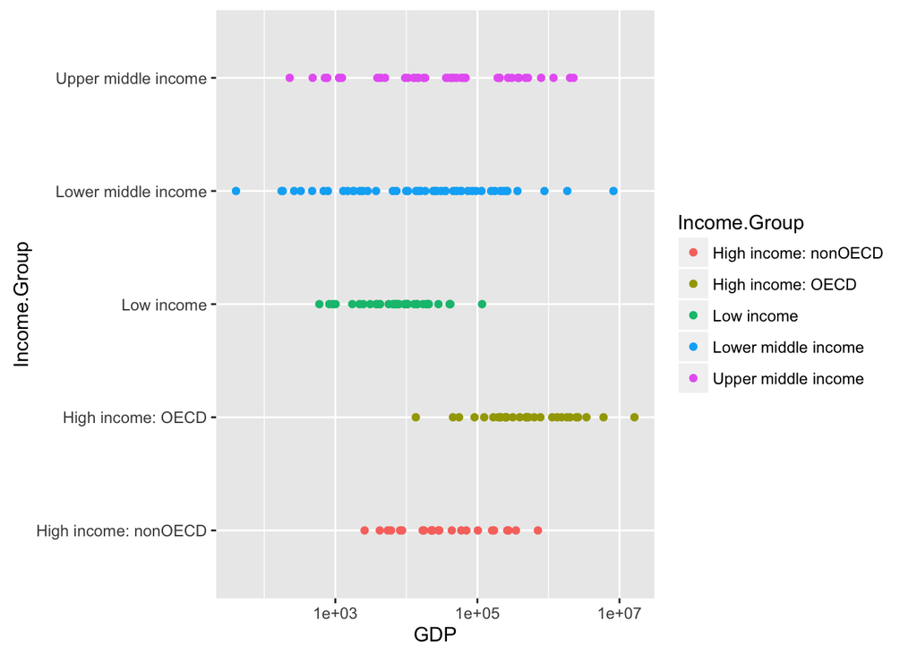

```r
ggplot(GDP_final_nan_sort)+ geom_point(aes(x= GDP,y=Income.Group,colour=Income.Group)) + scale_x_log10()
```

From this scatter plot we are able to see the distribution of Countries and the Income Groups they fall into.

GDP for each Country by Rank colored by Income Group:

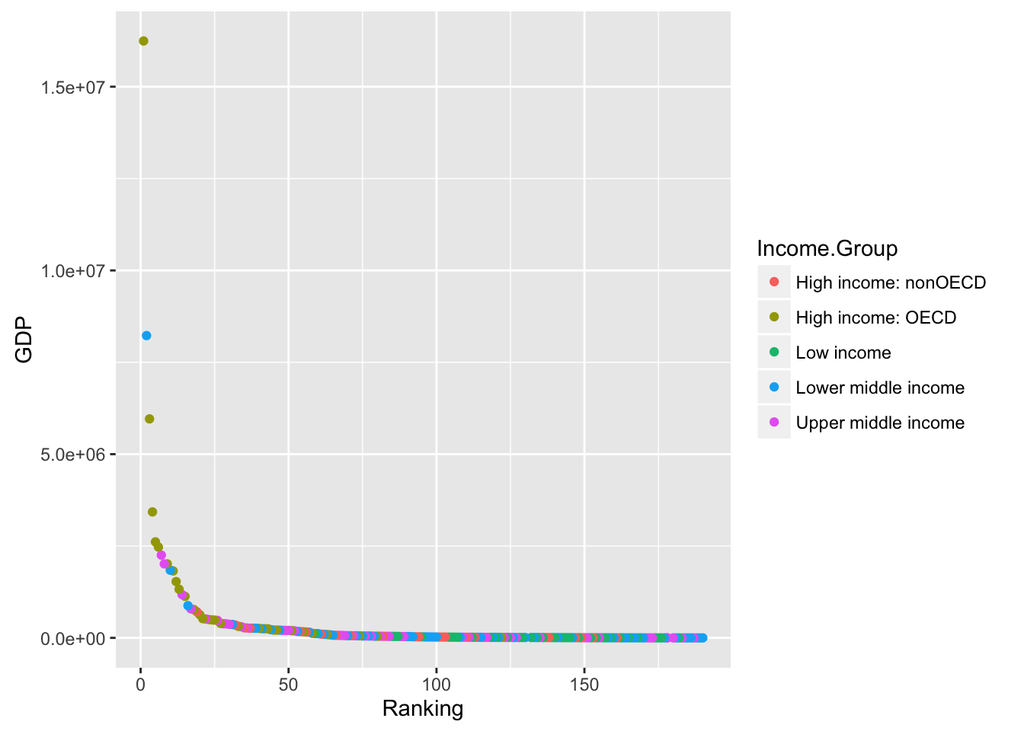

```r
ggplot(GDP_final_nan_sort)+ geom_point(aes(x= Ranking,y=GDP,colour=Income.Group))
```

## Analysis 5

Cut the GDP ranking into 5 separate quantile groups. Make a table versus Income.Group. How many countries are Lower middle income but among the 38 nations with highest GDP?

```r
#Question 5:
GDP_final_nan_sort$Group <- cut(GDP_final_nan_sort$Ranking, breaks = 5)
table(GDP_final_nan_sort$Group, GDP_final_nan_sort$Income.Group)
```

```
##
##                   High income: nonOECD High income: OECD Low income
##   (0.811,38.8]  0                    4                18          0
##   (38.8,76.6]   0                    5                10          1
##   (76.6,114]    0                    8                 1          9
##   (114,152]     0                    4                 1         16
##   (152,190]     0                    2                 0         11
##
##                Lower middle income Upper middle income
##   (0.811,38.8]                   5                  11
##   (38.8,76.6]                   13                   9
##   (76.6,114]                    12                   8
##   (114,152]                      8                   8
##   (152,190]                     16                   9
```

```r
top_ranked_lower_income <- GDP_final_nan_sort[which(GDP_final_nan_sort$Income.Group == "Lower middle income" & GDP_final_nan_sort$Group == "(0.811,38.8]"),]
```

There are five countries that are in the top 38 highest GDP countries and in the lower middle income group. The five countries that fall into this catergory are: Egypt, Thailand, Indonesia, India and China

# Conclusion